# 5A-Python Input and Output Handling

```python
from __future__ import print_function
```

## Python with Text File

```python
%%writefile dog_breeds.txt
Pug
Jack Russell Terrier
English Springer Spaniel
German Shepherd
Staffordshire Bull Terrier
Cavalier King Charles Spaniel
Golden Retriever
West Highland White Terrier
Boxer
Border Terrier
```

```
Writing dog_breeds.txt
```

```python
with open('dog_breeds.txt', 'r') as reader:
    print(reader.read())
```

```
Pug
Jack Russell Terrier
English Springer Spaniel
German Shepherd
Staffordshire Bull Terrier
Cavalier King Charles Spaniel
Golden Retriever
West Highland White Terrier
Boxer
Border Terrier
```

```python
f = open('dog_breeds.txt')
ListLine = f.readlines()
display(ListLine)
```

```
['Pug\n',
 'Jack Russell Terrier\n',
 'English Springer Spaniel\n',
 'German Shepherd\n',
 'Staffordshire Bull Terrier\n',
 'Cavalier King Charles Spaniel\n',
 'Golden Retriever\n',
 'West Highland White Terrier\n',
 'Boxer\n',
 'Border Terrier\n']
```

```python
f = open('dog_breeds.txt')
display(list(f))
```

```
['Pug\n',
 'Jack Russell Terrier\n',
 'English Springer Spaniel\n',
 'German Shepherd\n',
 'Staffordshire Bull Terrier\n',
 'Cavalier King Charles Spaniel\n',
 'Golden Retriever\n',
 'West Highland White Terrier\n',
 'Boxer\n',
 'Border Terrier\n']
```

```python
with open('dog_breeds.txt', 'r') as reader:
    for line in reader.readlines():
        print(line, end='')
```

```
Pug
Jack Russell Terrier
English Springer Spaniel
German Shepherd
Staffordshire Bull Terrier
Cavalier King Charles Spaniel
Golden Retriever
West Highland White Terrier
Boxer
Border Terrier
```

```python
with open('dog_breeds.txt', 'r') as reader:
    # Note: readlines doesn't trim the line endings
    dog_breeds = reader.readlines()

with open('dog_breeds_reversed.txt', 'w') as writer:
    # Alternatively you could use
    # writer.writelines(reversed(dog_breeds))

    # Write the dog breeds to the file in reversed order
    for breed in reversed(dog_breeds):
        writer.write(breed)
```

```python
with open('dog_breeds.txt', 'a') as a_writer:
    a_writer.write('\n\tBeagle')

with open('dog_breeds.txt', 'r') as reader:
    for line in reader.readlines():
        print(line, end='')
```

```
Pug
Jack Russell Terrier
English Springer Spaniel
German Shepherd
Staffordshire Bull Terrier
Cavalier King Charles Spaniel
Golden Retriever
West Highland White Terrier
Boxer
Border Terrier

	Beagle
```

## Exception Handling

```python
# import module sys to get the type of exception
import sys
randomList = ['a', 0, 2]
for entry in randomList:
    try:
        print("The entry is", entry)
        r = 1/int(entry)
        break
    except:
        print("Oops!", sys.exc_info()[0], "occurred.")
        print("Next entry.")
        print()
print("The reciprocal of", entry, "is", r)
```

```
The entry is a
Oops! <class 'ValueError'> occurred.
Next entry.

The entry is 0
Oops! <class 'ZeroDivisionError'> occurred.
Next entry.

The entry is 2
The reciprocal of 2 is 0.5
```

```python
raise KeyboardInterrupt
```

```
---------------------------------------------------------------------------
KeyboardInterrupt                         Traceback (most recent call last)
<ipython-input-10-c761920b81b0> in <module>
----> 1 raise KeyboardInterrupt

KeyboardInterrupt:
```

```python
raise MemoryError("This is an argument")
```

```
---------------------------------------------------------------------------
MemoryError                               Traceback (most recent call last)
<ipython-input-11-51782e52f201> in <module>
----> 1 raise MemoryError("This is an argument")

MemoryError: This is an argument
```

```python
try:
    a = int(input("Enter a positive integer: "))
    if a <= 0:
        raise ValueError("That is not a positive number!")
except ValueError as ve:
    print(ve)
```

```
Enter a positive integer: -1
That is not a positive number!
```

```python
# program to print the reciprocal of even numbers

try:
    num = int(input("Enter a number: "))
    assert num % 2 == 0
except:
    print("Not an even number!")
else:
    reciprocal = 1/num
```

```
Enter a number: 0
```

```
---------------------------------------------------------------------------
ZeroDivisionError                         Traceback (most recent call last)
<ipython-input-13-e49ee80ba8f8> in <module>
      7     print("Not an even number!")
      8 else:
----> 9     reciprocal = 1/num

ZeroDivisionError: division by zero
```

```python
try:
    print("==File Open==")
    f = open('dog_breeds.txt')
    display(list(f))
finally:
    print("==File Closed==")
    f.close()
```

```
==File Open==
```

```
['Pug\n',
 'Jack Russell Terrier\n',
 'English Springer Spaniel\n',
 'German Shepherd\n',
 'Staffordshire Bull Terrier\n',
 'Cavalier King Charles Spaniel\n',
 'Golden Retriever\n',
 'West Highland White Terrier\n',
 'Boxer\n',
 'Border Terrier\n',
 '\n',
 '\tBeagle']
```

```
==File Closed==
```

# What is XML?

- XML, or Extensible Markup Language, is a markup-language that is commonly used to structure, store, and transfer data between systems.
- With Python being a popular language for the web and data analysis, it's likely you'll need to read or write XML data at some point, in which case you're in luck.
- The ElementTree module for reading, writing, and modifying XML data.

```python
%%writefile items.xml
<data>
    <items>
        <item name="item1">item1abc</item>
        <item name="item2">item2abc</item>
    </items>
</data>
```

```
Writing items.xml
```

```python
from xml.dom import minidom
# parse an xml file by name
mydoc = minidom.parse('items.xml')
```

```python
items = mydoc.getElementsByTagName('item')

# one specific item attribute
print('Item #2 attribute:')
print(items[1].attributes['name'].value)

# all item attributes
print('\nAll attributes:')
for elem in items:
    print(elem.attributes['name'].value)

# one specific item's data
print('\nItem #2 data:')
print(items[1].firstChild.data)
print(items[1].childNodes[0].data)

# all items data
print('\nAll item data:')
for elem in items:
    print(elem.firstChild.data)
```

```
Item #2 attribute:
item2

All attributes:
item1
item2

Item #2 data:
item2abc
item2abc

All item data:
item1abc
item2abc
```

```python
%%writefile xmldemo.py
from xml.dom import minidom
# parse an xml file by name
mydoc = minidom.parse('items.xml')
items = mydoc.getElementsByTagName('item')

# one specific item attribute
print('Item #2 attribute:')
print(items[1].attributes['name'].value)

# all item attributes
print('\nAll attributes:')
for elem in items:
    print(elem.attributes['name'].value)

# one specific item's data
print('\nItem #2 data:')
print(items[1].firstChild.data)
print(items[1].childNodes[0].data)

# all items data
print('\nAll item data:')
for elem in items:
    print(elem.firstChild.data)
```

```
Writing xmldemo.py
```

```python
# Window > Type Anaconda Prompt
# Type D: (Enter)
# cd D:\TUANTA\VTC Academiy\AI-Tuan-Class\Python Developer 05 - Input and Output Handling\
# python xmldemo.py
# exit
```

```python
import xml.etree.ElementTree as ET
tree = ET.parse('items.xml')
root = tree.getroot()

# one specific item attribute
print('Item #2 attribute:')
print(root[0][1].attrib)

# all item attributes
print('\nAll attributes:')
for elem in root:
    for subelem in elem:
        print(subelem.attrib)

# one specific item's data
print('\nItem #2 data:')
print(root[0][1].text)

# all items data
print('\nAll item data:')
for elem in root:
    for subelem in elem:
        print(subelem.text)
```

```
Item #2 attribute:
{'name': 'item2'}

All attributes:
{'name': 'item1'}
{'name': 'item2'}

Item #2 data:
item2abc

All item data:
item1abc
item2abc
```

```python
import xml.etree.ElementTree as ET

# create the file structure
data = ET.Element('data')
items = ET.SubElement(data, 'items')
item1 = ET.SubElement(items, 'item')
item2 = ET.SubElement(items, 'item')
item1.set('name','item1')
item2.set('name','item2')
item1.text = 'item1abc'
item2.text = 'item2abc'

print(data)
# # create a new XML file with the results
mydata = ET.tostring(data, encoding='unicode')
print(mydata, type(mydata))
myfile = open("items2.xml", "w")
myfile.write(mydata)
myfile.close()
```

```
<Element 'data' at 0x000001D0E2A9D3B8>
<data><items><item name="item1">item1abc</item><item name="item2">item2abc</item></items></data> <class 'str'>
```

```python
for elem in root:
    for subelem in elem.findall('item'):

        # if we don't need to know the name of the attribute(s), get the dict
        print(subelem.attrib)

        # if we know the name of the attribute, access it directly
        print(subelem.get('name'))
```

```
{'name': 'item1'}
item1
{'name': 'item2'}
item2
```

```python
import xml.etree.ElementTree as ET

tree = ET.parse('items.xml')
root = tree.getroot()

# changing a field text
for elem in root.iter('item'):
    elem.text = 'new text'

# modifying an attribute
for elem in root.iter('item'):
    elem.set('name', 'newitem')

# adding an attribute
for elem in root.iter('item'):
    elem.set('name2', 'newitem2')

tree.write('newitems.xml')
```

```python
# Creating XML Sub-Elements
import xml.etree.ElementTree as ET

tree = ET.parse('items.xml')
root = tree.getroot()

# adding an element to the root node
attrib = {}
element = root.makeelement('seconditems', attrib)
root.append(element)

# adding an element to the seconditem node
attrib = {'name2': 'secondname2'}
subelement = root[0][1].makeelement('seconditem', attrib)
ET.SubElement(root[1], 'seconditem', attrib)
root[1][0].text = 'seconditemabc'

# create a new XML file with the new element
tree.write('newitems2.xml')
```

```python
import xml.etree.ElementTree as ET

tree = ET.parse('items.xml')
root = tree.getroot()

# removing an attribute
root[0][0].attrib.pop('name', None)

# create a new XML file with the results
tree.write('newitems3.xml')
```

```python
import xml.etree.ElementTree as ET

tree = ET.parse('items.xml')
root = tree.getroot()

# removing one sub-element
root[0].remove(root[0][0])

# create a new XML file with the results
tree.write('newitems4.xml')
```

```python
import xml.etree.ElementTree as ET

tree = ET.parse('items.xml')
root = tree.getroot()

# removing all sub-elements of an element
root[0].clear()

# create a new XML file with the results
tree.write('newitems5.xml')
```

# What is JSON?

- JSON (JavaScript Object Notation) is a popular data format used for representing structured data.
- It is a text format that is language independent and can be used in Python, Perl among other languages.
- JSON format is used for data communications between servers and web applications.
- It is built on two structures:
- A collection of name/value pairs. This is realized as an object, record, dictionary, hash table, keyed list, or associative array.
- An ordered list of values. This is realized as an array, vector, list, or sequence.

```python
# JSON Data
```

- The main functions of JSON are:
- dump(): encoded string writing on file.
- load(): Decode while JSON file read.
- dumps(): encoding to JSON objects
- loads(): Decode the JSON string.
- Example of JSON Data

{ "stations": [ { "acronym": “BLD”, "name": "Boulder Colorado", "latitude”: 40.00, "longitude”: -105.25 }, { "acronym”: “BHD”, "name": "Baring Head Wellington New Zealand", "latitude": -41.28, "longitude": 174.87 } ] }

# Another Example of JSON Data

- We consider an online database, IP-API.com, that returns GeoIP data in JSON format. Simply opening http://ip-api.com/json/54.148.84.95 will return the following JSON result:

{ "as": "AS16509 Amazon.com, Inc.", "city": "Boardman", "country": "United States", "countryCode": "US", "isp": "Amazon", "lat": 45.8696, "lon": -119.688, "org": "Amazon", "query": "54.148.84.95", "region": "OR", "regionName": "Oregon", "status": "success", "timezone": "America/Los_Angeles", "zip": "97818" } To see your own Geolocation data in JSON format, just open http://ip-api.com/json/.

- The text in JSON is done through quoted string which contains value in key-value mapping within { }.
- JSON data representation is very similar to Python dictionaries.
- It supports primitive types, like strings and numbers, as well as nested lists and objects

# Convert Python Data Types into JSON

- Python objects and their equivalent conversion to JSON.

Python JSON Equivalent dict object list, tuple array str string int, float number True true False false None null

[output not shown]

```python
import json
```

```python
print("Dictionary: ", json.dumps({"name": "John", "age": 30}))
print("List:       ", json.dumps(["apple", "bananas"]))
print("Tuple:      ", json.dumps(("apple", "bananas")))
print("String:     ", json.dumps("hello"))
print("Integer:    ", json.dumps(42))
print("Float:      ", json.dumps(31.76))
print("True:       ", json.dumps(True))
print("False:      ", json.dumps(False))
print("None:       ", json.dumps(None))
```

```
Dictionary:  {"name": "John", "age": 30}
List:        ["apple", "bananas"]
Tuple:       ["apple", "bananas"]
String:      "hello"
Integer:     42
Float:       31.76
True:        true
False:       false
None:        null
```

## Convert JSON to Python Object (Dict)

```python
json_data = '{"acronym": "BLD", "name": "Boulder Colorado", "latitude": 40.00, "longitude": -105.25}'

print(json_data)

python_obj = json.loads(json_data)
print("Name:     ", python_obj["name"])
print("Acronym:  ", python_obj["acronym"])
print("Latitude: ", python_obj["latitude"])
print("Latitude: ", python_obj["longitude"])

print()
```

```
{"acronym": "BLD", "name": "Boulder Colorado", "latitude": 40.00, "longitude": -105.25}
Name:      Boulder Colorado
Acronym:   BLD
Latitude:  40.0
Latitude:  -105.25
```

```python
print(json.dumps(python_obj, sort_keys=True, indent=4))
```

```
{
    "acronym": "BLD",
    "latitude": 40.0,
    "longitude": -105.25,
    "name": "Boulder Colorado"
}
```

## Convert JSON to Python Object (List)

```python
array = '{"drinks": ["coffee", "tea", "water"]}'
data = json.loads(array)

print(json.dumps(data, sort_keys=True, indent=4))
print(data["drinks"])
for element in data["drinks"]:
    print(element)
```

```
{
    "drinks": [
        "coffee",
        "tea",
        "water"
    ]
}
['coffee', 'tea', 'water']
coffee
tea
water
```

## Convert JSON to Python Object

```python
json_input = '{"stations": [{"acronym": "BLD", \
                                "name": "Boulder Colorado", \
                            "latitude": 40.00, \
                            "longitude": -105.25}, \
                            {"acronym": "BHD", \
                             "name": "Baring Head Wellington New Zealand",\
                             "latitude": -41.28, \
                             "longitude": 174.87}]}'
```

```python
decoded = json.loads(json_input)
obj = decoded['stations']
print(obj, type(obj))
for x in decoded['stations']:
    print(x["name"])
```

```
[{'acronym': 'BLD', 'name': 'Boulder Colorado', 'latitude': 40.0, 'longitude': -105.25}, {'acronym': 'BHD', 'name': 'Baring Head Wellington New Zealand', 'latitude': -41.28, 'longitude': 174.87}] <class 'list'>
Boulder Colorado
Baring Head Wellington New Zealand
```

```python
print(json.dumps(decoded, sort_keys=True, indent=4))
```

```
{
    "stations": [
        {
            "acronym": "BLD",
            "latitude": 40.0,
            "longitude": -105.25,
            "name": "Boulder Colorado"
        },
        {
            "acronym": "BHD",
            "latitude": -41.28,
            "longitude": 174.87,
            "name": "Baring Head Wellington New Zealand"
        }
    ]
}
```

```python
json_input = json.dumps(decoded, sort_keys=True, indent=4)
print(json_input)
decoded = json.loads(json_input)
obj = decoded['stations']
print(obj, type(obj))
for x in decoded['stations']:
    print(x["name"])
```

```
{
    "stations": [
        {
            "acronym": "BLD",
            "latitude": 40.0,
            "longitude": -105.25,
            "name": "Boulder Colorado"
        },
        {
            "acronym": "BHD",
            "latitude": -41.28,
            "longitude": 174.87,
            "name": "Baring Head Wellington New Zealand"
        }
    ]
}
[{'acronym': 'BLD', 'latitude': 40.0, 'longitude': -105.25, 'name': 'Boulder Colorado'}, {'acronym': 'BHD', 'latitude': -41.28, 'longitude': 174.87, 'name': 'Baring Head Wellington New Zealand'}] <class 'list'>
Boulder Colorado
Baring Head Wellington New Zealand
```

## Convert Python Object (Dict) to JSON

```python
d = {}
d["name"] = "Boulder Colorado"
d["acronym"] = "BLD"
d["latitude"] = 40.00
d["longitude"] = -105.25
print(json.dumps(d, ensure_ascii=False))
```

```
{"name": "Boulder Colorado", "acronym": "BLD", "latitude": 40.0, "longitude": -105.25}
```

```python
x = {
  "name": "John",
  "age": 30,
  "married": True,
  "divorced": False,
  "children": ("Ann","Billy"),
  "pets": None,
  "cars": [
    {"model": "BMW 230", "mpg": 27.5},
    {"model": "Ford Edge", "mpg": 24.1}
  ]
}

print("Python Object: \n\t", x)
```

```
Python Object:
	 {'name': 'John', 'age': 30, 'married': True, 'divorced': False, 'children': ('Ann', 'Billy'), 'pets': None, 'cars': [{'model': 'BMW 230', 'mpg': 27.5}, {'model': 'Ford Edge', 'mpg': 24.1}]}
```

```python
for key in x:
    print(key+":\t", x[key])
```

```
name:	 John
age:	 30
married:	 True
divorced:	 False
children:	 ('Ann', 'Billy')
pets:	 None
cars:	 [{'model': 'BMW 230', 'mpg': 27.5}, {'model': 'Ford Edge', 'mpg': 24.1}]
```

```python
x_js = json.dumps(x)
print("Corresponding JSON Object: \n\t", x_js)
```

```
Corresponding JSON Object:
	 {"name": "John", "age": 30, "married": true, "divorced": false, "children": ["Ann", "Billy"], "pets": null, "cars": [{"model": "BMW 230", "mpg": 27.5}, {"model": "Ford Edge", "mpg": 24.1}]}
```

```python
y = json.loads(x_js)
for key in y:
    print(key+":\t", y[key])
```

```
name:	 John
age:	 30
married:	 True
divorced:	 False
children:	 ['Ann', 'Billy']
pets:	 None
cars:	 [{'model': 'BMW 230', 'mpg': 27.5}, {'model': 'Ford Edge', 'mpg': 24.1}]
```

## Convert Python String to JSON

```python
json_string = """
{
    "researcher": {
        "name": "Ford Prefect",
        "species": "Betelgeusian",
        "relatives": [
            {
                "name": "Zaphod Beeblebrox",
                "species": "Betelgeusian"
            }
        ]
    }
}
"""
data = json.loads(json_string)
print(json.dumps(data, sort_keys=True, indent=4))
```

```
{
    "researcher": {
        "name": "Ford Prefect",
        "relatives": [
            {
                "name": "Zaphod Beeblebrox",
                "species": "Betelgeusian"
            }
        ],
        "species": "Betelgeusian"
    }
}
```

## Serialization and Deserialization

Serialization

We use the dump() that takes two arguments:

- The data object to be serialized.
- The file object to which it will be written (Byte format).

```python
x
```

```
{'name': 'John',
 'age': 30,
 'married': True,
 'divorced': False,
 'children': ('Ann', 'Billy'),
 'pets': None,
 'cars': [{'model': 'BMW 230', 'mpg': 27.5},
  {'model': 'Ford Edge', 'mpg': 24.1}]}
```

```python
file_name =  "Sample.json"
with open(file_name, "w") as fid:
     json.dump(x, fid)
```

### Deserializing JSON

- The Deserialization is opposite of Serialization, i.e. conversion of JSON object into their respective Python objects.

```python
with open(file_name, "r") as fid:
     z = json.load(fid)

print(z)
for key in z:
    print(key+":\t", z[key])
```

```
{'name': 'John', 'age': 30, 'married': True, 'divorced': False, 'children': ['Ann', 'Billy'], 'pets': None, 'cars': [{'model': 'BMW 230', 'mpg': 27.5}, {'model': 'Ford Edge', 'mpg': 24.1}]}
name:	 John
age:	 30
married:	 True
divorced:	 False
children:	 ['Ann', 'Billy']
pets:	 None
cars:	 [{'model': 'BMW 230', 'mpg': 27.5}, {'model': 'Ford Edge', 'mpg': 24.1}]
```

### Example

Consider the following JSON data (from NASA's Astronomy Picture of the Day API) that we write in a file named apod.json.

```python
%%writefile apod.json
{
    "media_type": "image",
    "copyright": "Yin Hao",
    "date": "2018-10-30",
    "url": "https://apod.nasa.gov/apod/image/1810/Orionids_Hao_960.jpg",
    "explanation": "Meteors have been shooting out from the constellation of Orion. This was expected, as October is the time of year for the Orionids Meteor Shower.  Pictured here, over two dozen meteors were caught in successively added exposures last October over Wulan Hada volcano in Inner Mongolia, China. The featured image shows multiple meteor streaks that can all be connected to a single small region on the sky called the radiant, here visible just above and to the left of the belt of Orion, The Orionids meteors started as sand sized bits expelled from Comet Halley during one of its trips to the inner Solar System. Comet Halley is actually responsible for two known meteor showers, the other known as the Eta Aquarids and visible every May. An Orionids image featured on APOD one year ago today from the same location shows the same car. Next month, the Leonids Meteor Shower from Comet Tempel-Tuttle should also result in some bright meteor streaks. Follow APOD on: Facebook, Instagram, Reddit, or Twitter",
    "hdurl": "https://apod.nasa.gov/apod/image/1810/Orionids_Hao_2324.jpg",
    "title": "Orionids Meteors over Inner Mongolia",
    "service_version": "v1"
}
```

```
Writing apod.json
```

```python
# Read the file
with open("apod.json", "r") as f:
    json_text = f.read()
```

```python
# Decode the JSON string into a Python dictionary.
apod_dict = json.loads(json_text)
print(apod_dict['explanation'])
```

```
Meteors have been shooting out from the constellation of Orion. This was expected, as October is the time of year for the Orionids Meteor Shower.  Pictured here, over two dozen meteors were caught in successively added exposures last October over Wulan Hada volcano in Inner Mongolia, China. The feat…
```

```python
# Encode the Python dictionary into a JSON string.
new_json_string = json.dumps(apod_dict, indent=6)
print(new_json_string)
```

```
{
      "media_type": "image",
      "copyright": "Yin Hao",
      "date": "2018-10-30",
      "url": "https://apod.nasa.gov/apod/image/1810/Orionids_Hao_960.jpg",
      "explanation": "Meteors have been shooting out from the constellation of Orion. This was expected, as October is the time of year for the Orionids Meteor Shower.  Pictured here, over two dozen meteors were caught in successively added exposures last October over Wulan Hada volcano in Inner Mon…
      "hdurl": "https://apod.nasa.gov/apod/image/1810/Orionids_Hao_2324.jpg",
      "title": "Orionids Meteors over Inner Mongolia",
      "service_version": "v1"
}
```

```python
new_json_string = json.dumps(apod_dict, indent=6, sort_keys=True)
print(new_json_string)
```

```
{
      "copyright": "Yin Hao",
      "date": "2018-10-30",
      "explanation": "Meteors have been shooting out from the constellation of Orion. This was expected, as October is the time of year for the Orionids Meteor Shower.  Pictured here, over two dozen meteors were caught in successively added exposures last October over Wulan Hada volcano in Inner Mon…
      "hdurl": "https://apod.nasa.gov/apod/image/1810/Orionids_Hao_2324.jpg",
      "media_type": "image",
      "service_version": "v1",
      "title": "Orionids Meteors over Inner Mongolia",
      "url": "https://apod.nasa.gov/apod/image/1810/Orionids_Hao_960.jpg"
}
```

## First Example

```python
import urllib
url = "https://api.nasa.gov/planetary/apod?api_key=DEMO_KEY"
with urllib.request.urlopen(url) as page:
     page_content = page.read()
```

```python
# To turn it into a string, for example, we use the decode method:
page_content.decode('utf-8')
```

```
'{"date":"2021-08-07","explanation":"Get out your red-blue glasses and hover over the surface of Mars. Taken on July 24, the 3D color view is from the Mars Ingenuity Helicopter\'s 10th flight above the Red Planet. Two images from Ingenuity\'s color camera, both captured at an altitude of 12 meters (…
```

```python
# Process the data with JSON
json_page = json.loads(page_content)
```

```python
# print the keys
for x in json_page:
    print(x)
```

```
date
explanation
hdurl
media_type
service_version
title
url
```

```python
# print the keys
for x in json_page:
    print(x+" -->", json_page[x])
    print()
```

```
date --> 2021-08-07

explanation --> Get out your red-blue glasses and hover over the surface of Mars. Taken on July 24, the 3D color view is from the Mars Ingenuity Helicopter's 10th flight above the Red Planet. Two images from Ingenuity's color camera, both captured at an altitude of 12 meters (40 feet), but a few met…

hdurl --> https://apod.nasa.gov/apod/image/2108/PIA24688_RTE_Anaglyph.jpg

media_type --> image

service_version --> v1

title --> Jezero Crater: Raised Ridges in 3D

url --> https://apod.nasa.gov/apod/image/2108/PIA24688_RTE_Anaglyph1024.jpg
```

```python
from pprint import pprint
pprint(json_page)
```

```
{'date': '2021-08-07',
 'explanation': 'Get out your red-blue glasses and hover over the surface of '
                'Mars. Taken on July 24, the 3D color view is from the Mars '
                "Ingenuity Helicopter's 10th flight above the Red Planet. Two "
                "images from Ingenuity's color camera, both captured at an "
                'altitude of 12 meters (40 feet), but a few meters apart to '
                'provide a stereo perspective, were used to construct the '
                "color anaglyph. Ingenuity's stereo images were made at the "
                'request of the Mars Perseverance rover science team. The team '
                'is considering a visit to these raised ridges on the floor of '
                "Jezero Crater during Perseverance's first science campaign.",
 'hdurl': 'https://apod.nasa.gov/apod/image/2108/PIA24688_RTE_Anaglyph.jpg',
 'media_type': 'image',
 'service_version': 'v1',
 'title': 'Jezero Crater: Raised Ridges in 3D',
 'url': 'https://apod.nasa.gov/apod/image/2108/PIA24688_RTE_Anaglyph1024.jpg'}
```

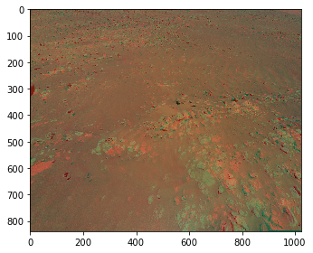

```python
%matplotlib inline
from skimage import io

io.imshow(io.imread(json_page["url"]))
io.show()
```

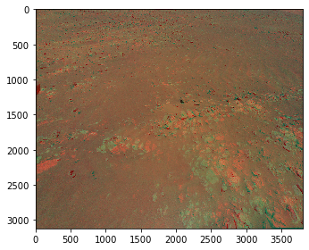

```python
io.imshow(io.imread(json_page["hdurl"]))
io.show()
```

## Second Example

We will fetch data of CityBike NYC (Bike Sharing System) from specified https://feeds.citibikenyc.com/stations/stations.json and convert into dictionary format.

```python
import requests

# Get JSON string data from CityBike NYC using web requests library
json_response= requests.get("https://feeds.citibikenyc.com/stations/stations.json")

# Check type of json_response object
print(type(json_response.text))
```

```
<class 'str'>
```

```python
# Load data in loads() function of json library
bike_dict = json.loads(json_response.text)
```

```python
# Load data in loads() function of json library
bike_dict = json.loads(json_response.text)
```

```python
# List all the keys
for key in bike_dict:
    print(key)
```

```
executionTime
stationBeanList
```

```python
# Get stationBeanList key data from dict
print(bike_dict['stationBeanList'][0])
```

```
{'id': 72, 'stationName': 'W 52 St & 11 Ave', 'availableDocks': 32, 'totalDocks': 39, 'latitude': 40.76727216, 'longitude': -73.99392888, 'statusValue': 'In Service', 'statusKey': 1, 'availableBikes': 7, 'stAddress1': 'W 52 St & 11 Ave', 'stAddress2': '', 'city': '', 'postalCode': '', 'location': ''…
```

```python
print(json.dumps(bike_dict['stationBeanList'][0], indent=3))
```

```
{
   "id": 72,
   "stationName": "W 52 St & 11 Ave",
   "availableDocks": 32,
   "totalDocks": 39,
   "latitude": 40.76727216,
   "longitude": -73.99392888,
   "statusValue": "In Service",
   "statusKey": 1,
   "availableBikes": 7,
   "stAddress1": "W 52 St & 11 Ave",
   "stAddress2": "",
   "city": "",
   "postalCode": "",
   "location": "",
   "altitude": "",
   "testStation": false,
   "lastCommunicationTime": "2016-01-22 04:30:15 PM",
   "landMark": ""
}
```

## Conclusion

- JSON is standardized and language-independent (while pickle is specific to Python).
- It is more secure and much faster than pickle.
- If you only need to use Python, then the pickle module is still a good choice for its ease of use and ability to reconstruct - complete Python objects.

## Reference Documents

Working With JSON Data in Python

## What is JSON?

JSON (JavaScript Object Notation) is a popular data format used for representing structured data. It is a text format that is language independent and can be used in Python, Perl among other languages. JSON format is used for data communications between servers and web applications. It is built on two structures:

A collection of name/value pairs. This is realized as an object, record, dictionary, hash table, keyed list, or associative array. An ordered list of values. This is realized as an array, vector, list, or sequence.